# Client Report - Can You Predict That?

Course DS 250

Author

[STUDENT NAME]

```python
import pandas as pd
import numpy as np
from lets_plot import *

# add the additional libraries you need to import for ML here

LetsPlot.setup_html(isolated_frame=True)
```

```python
# Learn morea about Code Cells: https://quarto.org/docs/reference/cells/cells-jupyter.html

# Include and execute your code here

# import your data here using pandas and the URL
url = "https://raw.githubusercontent.com/byuidatascience/data4dwellings/master/data-raw/dwellings_ml/dwellings_ml.csv"
dwellings_ml = pd.read_csv(url)

# quick check
dwellings_ml.head()
```

|  | parcel | abstrprd | livearea | finbsmnt | basement | yrbuilt | totunits | stories | nocars | numbdrm | ... | arcstyle_THREE-STORY | arcstyle_TRI-LEVEL | arcstyle_TRI-LEVEL WITH BASEMENT | arcstyle_TWO AND HALF-STORY | arcstyle_TWO-STORY | qualified_Q | qualified_U | status_I | status_V | before1980 |
| --- | --- | --- | --- | --- | --- | --- | --- | --- | --- | --- | --- | --- | --- | --- | --- | --- | --- | --- | --- | --- | --- |
| 0 | 00102-08-065-065 | 1130 | 1346 | 0 | 0 | 2004 | 1 | 2 | 2 | 2 | ... | 0 | 0 | 0 | 0 | 0 | 1 | 0 | 1 | 0 | 0 |
| 1 | 00102-08-073-073 | 1130 | 1249 | 0 | 0 | 2005 | 1 | 1 | 1 | 2 | ... | 0 | 0 | 0 | 0 | 0 | 1 | 0 | 1 | 0 | 0 |
| 2 | 00102-08-078-078 | 1130 | 1346 | 0 | 0 | 2005 | 1 | 2 | 1 | 2 | ... | 0 | 0 | 0 | 0 | 0 | 1 | 0 | 1 | 0 | 0 |
| 3 | 00102-08-081-081 | 1130 | 1146 | 0 | 0 | 2005 | 1 | 1 | 0 | 2 | ... | 0 | 0 | 0 | 0 | 0 | 1 | 0 | 1 | 0 | 0 |
| 4 | 00102-08-086-086 | 1130 | 1249 | 0 | 0 | 2005 | 1 | 1 | 1 | 2 | ... | 0 | 0 | 0 | 0 | 0 | 0 | 1 | 1 | 0 | 0 |

5 rows × 51 columns

```python
# original exploration code
dwellings_ml.shape
dwellings_ml.head()
dwellings_ml.columns
dwellings_ml.info()
dwellings_ml.describe().T
```

```
<class 'pandas.DataFrame'>
RangeIndex: 22913 entries, 0 to 22912
Data columns (total 51 columns):
 #   Column                            Non-Null Count  Dtype
---  ------                            --------------  -----
 0   parcel                            22913 non-null  str
 1   abstrprd                          22913 non-null  int64
 2   livearea                          22913 non-null  int64
 3   finbsmnt                          22913 non-null  int64
 4   basement                          22913 non-null  int64
 5   yrbuilt                           22913 non-null  int64
 6   totunits                          22913 non-null  int64
 7   stories                           22913 non-null  int64
 8   nocars                            22913 non-null  int64
 9   numbdrm                           22913 non-null  int64
```

[output cut: 43 more lines]

|  | count | mean | std | min | 25% | 50% | 75% | max |
| --- | --- | --- | --- | --- | --- | --- | --- | --- |
| abstrprd | 22913.0 | 1118.980099 | 1.526031e+02 | 100.0 | 1112.0 | 1112.0 | 1114.0 | 9279.0 |
| livearea | 22913.0 | 1510.783485 | 7.870181e+02 | 293.0 | 975.0 | 1302.0 | 1823.0 | 21503.0 |
| finbsmnt | 22913.0 | 330.511936 | 4.699125e+02 | 0.0 | 0.0 | 0.0 | 716.0 | 4320.0 |
| basement | 22913.0 | 524.501942 | 5.676530e+02 | 0.0 | 0.0 | 401.0 | 959.0 | 9025.0 |
| yrbuilt | 22913.0 | 1963.685506 | 3.692870e+01 | 1873.0 | 1940.0 | 1963.0 | 2002.0 | 2013.0 |
| totunits | 22913.0 | 1.018461 | 2.563093e-01 | 0.0 | 1.0 | 1.0 | 1.0 | 10.0 |
| stories | 22913.0 | 1.419849 | 5.688865e-01 | 1.0 | 1.0 | 1.0 | 2.0 | 4.0 |
| nocars | 22913.0 | 1.362589 | 1.097619e+00 | 0.0 | 0.0 | 2.0 | 2.0 | 17.0 |
| numbdrm | 22913.0 | 2.522062 | 8.846016e-01 | 0.0 | 2.0 | 2.0 | 3.0 | 9.0 |
| numbaths | 22913.0 | 2.351416 | 1.117339e+00 | 0.0 | 2.0 | 2.0 | 3.0 | 11.0 |
| sprice | 22913.0 | 561859.636189 | 2.135231e+06 | 1000.0 | 134000.0 | 230000.0 | 378400.0 | 21750000.0 |
| deduct | 22913.0 | 1336.948850 | 3.061790e+03 | 0.0 | 0.0 | 0.0 | 2383.0 | 101809.0 |
| netprice | 22913.0 | 560522.687339 | 2.135373e+06 | 1000.0 | 132000.0 | 229000.0 | 375500.0 | 21750000.0 |
| tasp | 22913.0 | 563820.728538 | 2.135272e+06 | 1000.0 | 132890.0 | 231000.0 | 382184.0 | 21750000.0 |
| smonth | 22913.0 | 6.540348 | 3.268072e+00 | 1.0 | 4.0 | 6.0 | 9.0 | 12.0 |
| syear | 22913.0 | 2011.064723 | 7.088026e-01 | 2010.0 | 2011.0 | 2011.0 | 2012.0 | 2012.0 |
| condition_AVG | 22913.0 | 0.777157 | 4.161628e-01 | 0.0 | 1.0 | 1.0 | 1.0 | 1.0 |
| condition_Excel | 22913.0 | 0.001091 | 3.301425e-02 | 0.0 | 0.0 | 0.0 | 0.0 | 1.0 |
| condition_Fair | 22913.0 | 0.000044 | 6.606311e-03 | 0.0 | 0.0 | 0.0 | 0.0 | 1.0 |
| condition_Good | 22913.0 | 0.205822 | 4.043098e-01 | 0.0 | 0.0 | 0.0 | 0.0 | 1.0 |
| condition_VGood | 22913.0 | 0.015886 | 1.250380e-01 | 0.0 | 0.0 | 0.0 | 0.0 | 1.0 |
| quality_A | 22913.0 | 0.041461 | 1.993587e-01 | 0.0 | 0.0 | 0.0 | 0.0 | 1.0 |
| quality_B | 22913.0 | 0.259940 | 4.386109e-01 | 0.0 | 0.0 | 0.0 | 1.0 | 1.0 |
| quality_C | 22913.0 | 0.674595 | 4.685361e-01 | 0.0 | 0.0 | 1.0 | 1.0 | 1.0 |
| quality_D | 22913.0 | 0.017239 | 1.301640e-01 | 0.0 | 0.0 | 0.0 | 0.0 | 1.0 |
| quality_X | 22913.0 | 0.006765 | 8.197103e-02 | 0.0 | 0.0 | 0.0 | 0.0 | 1.0 |
| gartype_Att | 22913.0 | 0.372932 | 4.835949e-01 | 0.0 | 0.0 | 0.0 | 1.0 | 1.0 |
| gartype_Att/Det | 22913.0 | 0.009165 | 9.529690e-02 | 0.0 | 0.0 | 0.0 | 0.0 | 1.0 |
| gartype_CP | 22913.0 | 0.003753 | 6.115066e-02 | 0.0 | 0.0 | 0.0 | 0.0 | 1.0 |
| gartype_Det | 22913.0 | 0.304412 | 4.601681e-01 | 0.0 | 0.0 | 0.0 | 1.0 | 1.0 |
| gartype_None | 22913.0 | 0.304543 | 4.602238e-01 | 0.0 | 0.0 | 0.0 | 1.0 | 1.0 |
| gartype_att/CP | 22913.0 | 0.000655 | 2.557831e-02 | 0.0 | 0.0 | 0.0 | 0.0 | 1.0 |
| gartype_det/CP | 22913.0 | 0.004539 | 6.721982e-02 | 0.0 | 0.0 | 0.0 | 0.0 | 1.0 |
| arcstyle_BI-LEVEL | 22913.0 | 0.008161 | 8.997251e-02 | 0.0 | 0.0 | 0.0 | 0.0 | 1.0 |
| arcstyle_CONVERSIONS | 22913.0 | 0.005543 | 7.424435e-02 | 0.0 | 0.0 | 0.0 | 0.0 | 1.0 |
| arcstyle_END UNIT | 22913.0 | 0.195391 | 3.965103e-01 | 0.0 | 0.0 | 0.0 | 0.0 | 1.0 |
| arcstyle_MIDDLE UNIT | 22913.0 | 0.133811 | 3.404560e-01 | 0.0 | 0.0 | 0.0 | 0.0 | 1.0 |
| arcstyle_ONE AND HALF-STORY | 22913.0 | 0.036180 | 1.867427e-01 | 0.0 | 0.0 | 0.0 | 0.0 | 1.0 |
| arcstyle_ONE-STORY | 22913.0 | 0.375682 | 4.843090e-01 | 0.0 | 0.0 | 0.0 | 1.0 | 1.0 |
| arcstyle_SPLIT LEVEL | 22913.0 | 0.001658 | 4.069114e-02 | 0.0 | 0.0 | 0.0 | 0.0 | 1.0 |
| arcstyle_THREE-STORY | 22913.0 | 0.001615 | 4.015304e-02 | 0.0 | 0.0 | 0.0 | 0.0 | 1.0 |
| arcstyle_TRI-LEVEL | 22913.0 | 0.011827 | 1.081109e-01 | 0.0 | 0.0 | 0.0 | 0.0 | 1.0 |
| arcstyle_TRI-LEVEL WITH BASEMENT | 22913.0 | 0.014010 | 1.175323e-01 | 0.0 | 0.0 | 0.0 | 0.0 | 1.0 |
| arcstyle_TWO AND HALF-STORY | 22913.0 | 0.007201 | 8.455535e-02 | 0.0 | 0.0 | 0.0 | 0.0 | 1.0 |
| arcstyle_TWO-STORY | 22913.0 | 0.208921 | 4.065465e-01 | 0.0 | 0.0 | 0.0 | 0.0 | 1.0 |
| qualified_Q | 22913.0 | 0.673853 | 4.688119e-01 | 0.0 | 0.0 | 1.0 | 1.0 | 1.0 |
| qualified_U | 22913.0 | 0.326147 | 4.688119e-01 | 0.0 | 0.0 | 0.0 | 1.0 | 1.0 |
| status_I | 22913.0 | 0.945926 | 2.261688e-01 | 0.0 | 1.0 | 1.0 | 1.0 | 1.0 |
| status_V | 22913.0 | 0.054074 | 2.261688e-01 | 0.0 | 0.0 | 0.0 | 0.0 | 1.0 |
| before1980 | 22913.0 | 0.624929 | 4.841518e-01 | 0.0 | 0.0 | 1.0 | 1.0 | 1.0 |

## QUESTION|TASK 1

**Create 2-3 charts that evaluate potential relationships between the home variables and `before1980`.** Explain what you learn from the charts that could help a machine learning algorithm.

*These are two insightful charts that display the differences in data over the years. We can see the relationship of data found before and after the year 1980. Some trends are more visible than other, but this helps us group together data for a machine learning model. This could help when figuring out whether a house was built before the 80s or not.*

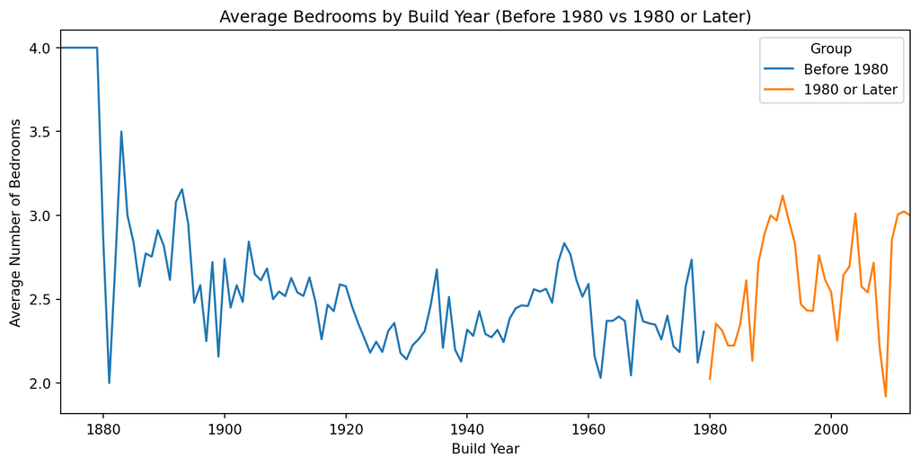

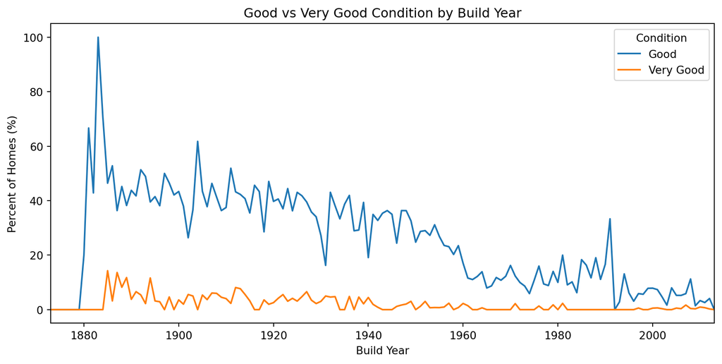

```python
# Include and execute your code here

import seaborn as sns
import matplotlib.pyplot as plt

# Chart 1:Comparison of the average number of bedrooms by year from before1980 and after.

# Clean the data to only use relevant rows that exist.
bedrooms_by_year = (
  dwellings_ml
  .dropna(subset=["yrbuilt", "numbdrm", "before1980"])
  # Use integer values
  .assign(yrbuilt=lambda df: df["yrbuilt"].astype(int))
  # .mean() can get the average of any data with input.
  .groupby(["yrbuilt", "before1980"], as_index=False)["numbdrm"]
  .mean()
  # Makes the years appear neatly
  .sort_values("yrbuilt")
)

# It's important when coding in any instance to add insightful names/labels to all the data you're working with or it'll get messy real quick.
bedrooms_by_year["period"] = bedrooms_by_year["before1980"].replace({
  1: "Before 1980",
  0: "1980 or Later"
})

# Line chart code.
plt.figure(figsize=(11, 5))
sns.lineplot(data=bedrooms_by_year, x="yrbuilt", y="numbdrm", hue="period")
plt.title("Average Bedrooms by Build Year (Before 1980 vs 1980 or Later)")
plt.xlabel("Build Year")
plt.ylabel("Average Number of Bedrooms")
#This is how to get all available years possible
plt.xlim(bedrooms_by_year["yrbuilt"].min(), bedrooms_by_year["yrbuilt"].max())
plt.legend(title="Group")
plt.show()

# Chart 2: Good vs Very Good condition by year
# Step 1: Following the same cleaning process as we did for the first chart
condition_by_year = (
  dwellings_ml
  .dropna(subset=["yrbuilt", "condition_Good", "condition_VGood"])
  # Step 2: Same process
  .assign(yrbuilt=lambda df: df["yrbuilt"].astype(int))
  # Step 3: Using the mean again
  .groupby("yrbuilt", as_index=False)[["condition_Good", "condition_VGood"]]
  .mean()
  # Step 4: Same process for year.
  .sort_values("yrbuilt")
)

# Step 5: How to get percentages.
condition_by_year["pct_good"] = condition_by_year["condition_Good"] * 100
condition_by_year["pct_vgood"] = condition_by_year["condition_VGood"] * 100

# Step 6: How to get them to display side by side.
condition_long = condition_by_year.melt(
  id_vars="yrbuilt",
  value_vars=["pct_good", "pct_vgood"],
  var_name="condition_type",
  value_name="percent"
)

# Step 7: Same process of labeling.
condition_long["condition_type"] = condition_long["condition_type"].replace({
  "pct_good": "Good",
  "pct_vgood": "Very Good"
})

# Step 8: How to show the two lines on a chart.
plt.figure(figsize=(11, 5))
sns.lineplot(data=condition_long, x="yrbuilt", y="percent", hue="condition_type")
plt.title("Good vs Very Good Condition by Build Year")
plt.xlabel("Build Year")
plt.ylabel("Percent of Homes (%)")
# Step 9:Same process to get all years possible.
plt.xlim(condition_by_year["yrbuilt"].min(), condition_by_year["yrbuilt"].max())
plt.legend(title="Condition")
plt.show()
```

## QUESTION|TASK 2

**Build a classification model labeling houses as being built “before 1980” or “during or after 1980”.** Your goal is to reach or exceed 90% accuracy. Explain your final model choice (algorithm, tuning parameters, etc) and describe what other models you tried.

```python
# Include and execute your code here

from sklearn.model_selection import train_test_split
from sklearn.ensemble import RandomForestClassifier
from sklearn.metrics import accuracy_score, classification_report

condition_columns = [col for col in dwellings_ml.columns if col.startswith("condition_")]

X = dwellings_ml[condition_columns]
y = dwellings_ml["before1980"]

X_train, X_test, y_train, y_test = train_test_split(
  X, y, test_size=0.2, random_state=42, stratify=y
)

condition_model = RandomForestClassifier(
  n_estimators=300,
  max_depth=8,
  random_state=42
)
condition_model.fit(X_train, y_train)

y_pred = condition_model.predict(X_test)
accuracy = accuracy_score(y_test, y_pred)

print(f"Accuracy (condition_* only): {accuracy:.4f}")
print("\nClassification Report:")
print(classification_report(y_test, y_pred))
```

```
Accuracy (condition_* only): 0.6254

Classification Report:
              precision    recall  f1-score   support

           0       1.00      0.00      0.00      1719
           1       0.63      1.00      0.77      2864

    accuracy                           0.63      4583
   macro avg       0.81      0.50      0.39      4583
weighted avg       0.77      0.63      0.48      4583
```

## QUESTION|TASK 3

**Justify your classification model by discussing the most important features selected by your model.** This discussion should include a feature importance chart and a description of the features.

```python
# Include and execute your code here
```

## QUESTION|TASK 4

**Describe the quality of your classification model using 2-3 different evaluation metrics.** You also need to explain how to interpret each of the evaluation metrics you use.

```python
# Include and execute your code here
```

## STRETCH QUESTION|TASK 1

**Repeat the classification model using 3 different algorithms.** Display their Feature Importance, and Decision Matrix. Explian the differences between the models and which one you would recommend to the Client.

```python
# Include and execute your code here
```

## STRETCH QUESTION|TASK 2

**Join the `dwellings_neighborhoods_ml.csv` data to the `dwelling_ml.csv` on the `parcel` column to create a new dataset. Duplicate the code for the stretch question above and update it to use this data.** Explain the differences and if this changes the model you recomend to the Client.

```python
# Include and execute your code here
```

## STRETCH QUESTION|TASK 3

**Can you build a model that predicts the year a house was built?** Explain the model and the evaluation metrics you would use to determine if the model is good.

```python
# Include and execute your code here
```